# Optimal Treatment Analysis

## Outcome Variable

**Outcome Variable:** ever_wasted

## Predictor Variables

**Intervention Variable:** hhwealth_quart

**Adjustment Set:**

- arm
- sex
- W_mage
- meducyrs
- feducyrs
- W_gagebrth
- W_birthwt
- W_birthlen
- W_nchldlt5
- W_parity
- delta_W_mage
- delta_meducyrs
- delta_feducyrs
- delta_W_gagebrth
- delta_W_birthwt
- delta_W_birthlen
- delta_W_nchldlt5
- delta_W_parity

## Stratifying Variables

The analysis was stratified on these variable(s):

- agecat
- studyid
- country

## Data Summary

| agecat | studyid | country | hhwealth_quart | ever_wasted | n_cell | n |
| --- | --- | --- | --- | --- | --- | --- |
| 0-24 months | ki0047075b-MAL-ED | BANGLADESH | Wealth Q4 | 0 | 17 | 82 |
| 0-24 months | ki0047075b-MAL-ED | BANGLADESH | Wealth Q4 | 1 | 4 | 82 |
| 0-24 months | ki0047075b-MAL-ED | BANGLADESH | Wealth Q1 | 0 | 11 | 82 |
| 0-24 months | ki0047075b-MAL-ED | BANGLADESH | Wealth Q1 | 1 | 10 | 82 |
| 0-24 months | ki0047075b-MAL-ED | BANGLADESH | Wealth Q2 | 0 | 9 | 82 |
| 0-24 months | ki0047075b-MAL-ED | BANGLADESH | Wealth Q2 | 1 | 11 | 82 |
| 0-24 months | ki0047075b-MAL-ED | BANGLADESH | Wealth Q3 | 0 | 15 | 82 |
| 0-24 months | ki0047075b-MAL-ED | BANGLADESH | Wealth Q3 | 1 | 5 | 82 |
| 0-24 months | ki0047075b-MAL-ED | INDIA | Wealth Q4 | 0 | 8 | 71 |
| 0-24 months | ki0047075b-MAL-ED | INDIA | Wealth Q4 | 1 | 10 | 71 |
| 0-24 months | ki0047075b-MAL-ED | INDIA | Wealth Q1 | 0 | 7 | 71 |
| 0-24 months | ki0047075b-MAL-ED | INDIA | Wealth Q1 | 1 | 12 | 71 |
| 0-24 months | ki0047075b-MAL-ED | INDIA | Wealth Q2 | 0 | 10 | 71 |
| 0-24 months | ki0047075b-MAL-ED | INDIA | Wealth Q2 | 1 | 7 | 71 |
| 0-24 months | ki0047075b-MAL-ED | INDIA | Wealth Q3 | 0 | 7 | 71 |
| 0-24 months | ki0047075b-MAL-ED | INDIA | Wealth Q3 | 1 | 10 | 71 |
| 0-24 months | ki0047075b-MAL-ED | NEPAL | Wealth Q4 | 0 | 10 | 42 |
| 0-24 months | ki0047075b-MAL-ED | NEPAL | Wealth Q4 | 1 | 1 | 42 |
| 0-24 months | ki0047075b-MAL-ED | NEPAL | Wealth Q1 | 0 | 7 | 42 |
| 0-24 months | ki0047075b-MAL-ED | NEPAL | Wealth Q1 | 1 | 4 | 42 |
| 0-24 months | ki0047075b-MAL-ED | NEPAL | Wealth Q2 | 0 | 8 | 42 |
| 0-24 months | ki0047075b-MAL-ED | NEPAL | Wealth Q2 | 1 | 2 | 42 |
| 0-24 months | ki0047075b-MAL-ED | NEPAL | Wealth Q3 | 0 | 7 | 42 |
| 0-24 months | ki0047075b-MAL-ED | NEPAL | Wealth Q3 | 1 | 3 | 42 |
| 0-24 months | ki0047075b-MAL-ED | PERU | Wealth Q4 | 0 | 8 | 37 |
| 0-24 months | ki0047075b-MAL-ED | PERU | Wealth Q4 | 1 | 2 | 37 |
| 0-24 months | ki0047075b-MAL-ED | PERU | Wealth Q1 | 0 | 8 | 37 |
| 0-24 months | ki0047075b-MAL-ED | PERU | Wealth Q1 | 1 | 1 | 37 |
| 0-24 months | ki0047075b-MAL-ED | PERU | Wealth Q2 | 0 | 7 | 37 |
| 0-24 months | ki0047075b-MAL-ED | PERU | Wealth Q2 | 1 | 2 | 37 |

[output cut: 378 more lines]

The following strata were considered:

- agecat: 0-24 months, studyid: ki0047075b-MAL-ED, country: BANGLADESH
- agecat: 0-24 months, studyid: ki0047075b-MAL-ED, country: INDIA
- agecat: 0-24 months, studyid: ki0047075b-MAL-ED, country: NEPAL
- agecat: 0-24 months, studyid: ki0047075b-MAL-ED, country: PERU
- agecat: 0-24 months, studyid: ki0047075b-MAL-ED, country: SOUTH AFRICA
- agecat: 0-24 months, studyid: ki0047075b-MAL-ED, country: TANZANIA, UNITED REPUBLIC OF
- agecat: 0-24 months, studyid: ki1000108-CMC-V-BCS-2002, country: INDIA
- agecat: 0-24 months, studyid: ki1000108-IRC, country: INDIA
- agecat: 0-24 months, studyid: ki1017093b-PROVIDE, country: BANGLADESH
- agecat: 0-24 months, studyid: ki1066203-TanzaniaChild2, country: TANZANIA, UNITED REPUBLIC OF
- agecat: 0-24 months, studyid: ki1113344-GMS-Nepal, country: NEPAL
- agecat: 0-24 months, studyid: ki1114097-CONTENT, country: PERU
- agecat: 0-24 months, studyid: ki1135781-COHORTS, country: GUATEMALA
- agecat: 0-24 months, studyid: ki1135781-COHORTS, country: PHILIPPINES
- agecat: 0-24 months, studyid: ki1148112-LCNI-5, country: MALAWI
- agecat: 0-24 months, studyid: kiGH5241-JiVitA-3, country: BANGLADESH
- agecat: 0-24 months, studyid: kiGH5241-JiVitA-4, country: BANGLADESH
- agecat: 0-6 months, studyid: ki0047075b-MAL-ED, country: BANGLADESH
- agecat: 0-6 months, studyid: ki0047075b-MAL-ED, country: INDIA
- agecat: 0-6 months, studyid: ki0047075b-MAL-ED, country: NEPAL
- agecat: 0-6 months, studyid: ki0047075b-MAL-ED, country: PERU
- agecat: 0-6 months, studyid: ki0047075b-MAL-ED, country: SOUTH AFRICA
- agecat: 0-6 months, studyid: ki0047075b-MAL-ED, country: TANZANIA, UNITED REPUBLIC OF
- agecat: 0-6 months, studyid: ki1000108-CMC-V-BCS-2002, country: INDIA
- agecat: 0-6 months, studyid: ki1000108-IRC, country: INDIA
- agecat: 0-6 months, studyid: ki1017093b-PROVIDE, country: BANGLADESH
- agecat: 0-6 months, studyid: ki1066203-TanzaniaChild2, country: TANZANIA, UNITED REPUBLIC OF
- agecat: 0-6 months, studyid: ki1113344-GMS-Nepal, country: NEPAL
- agecat: 0-6 months, studyid: ki1114097-CONTENT, country: PERU
- agecat: 0-6 months, studyid: ki1135781-COHORTS, country: GUATEMALA
- agecat: 0-6 months, studyid: ki1135781-COHORTS, country: PHILIPPINES
- agecat: 0-6 months, studyid: ki1148112-LCNI-5, country: MALAWI
- agecat: 0-6 months, studyid: kiGH5241-JiVitA-3, country: BANGLADESH
- agecat: 0-6 months, studyid: kiGH5241-JiVitA-4, country: BANGLADESH
- agecat: 6-24 months, studyid: ki0047075b-MAL-ED, country: BANGLADESH
- agecat: 6-24 months, studyid: ki0047075b-MAL-ED, country: INDIA
- agecat: 6-24 months, studyid: ki0047075b-MAL-ED, country: NEPAL
- agecat: 6-24 months, studyid: ki0047075b-MAL-ED, country: PERU
- agecat: 6-24 months, studyid: ki0047075b-MAL-ED, country: SOUTH AFRICA
- agecat: 6-24 months, studyid: ki0047075b-MAL-ED, country: TANZANIA, UNITED REPUBLIC OF
- agecat: 6-24 months, studyid: ki1000108-CMC-V-BCS-2002, country: INDIA
- agecat: 6-24 months, studyid: ki1000108-IRC, country: INDIA
- agecat: 6-24 months, studyid: ki1017093b-PROVIDE, country: BANGLADESH
- agecat: 6-24 months, studyid: ki1066203-TanzaniaChild2, country: TANZANIA, UNITED REPUBLIC OF
- agecat: 6-24 months, studyid: ki1113344-GMS-Nepal, country: NEPAL
- agecat: 6-24 months, studyid: ki1114097-CONTENT, country: PERU
- agecat: 6-24 months, studyid: ki1135781-COHORTS, country: GUATEMALA
- agecat: 6-24 months, studyid: ki1135781-COHORTS, country: PHILIPPINES
- agecat: 6-24 months, studyid: ki1148112-LCNI-5, country: MALAWI
- agecat: 6-24 months, studyid: kiGH5241-JiVitA-3, country: BANGLADESH
- agecat: 6-24 months, studyid: kiGH5241-JiVitA-4, country: BANGLADESH

### Dropped Strata

Some strata were dropped due to rare outcomes:

- agecat: 0-24 months, studyid: ki0047075b-MAL-ED, country: BANGLADESH
- agecat: 0-24 months, studyid: ki0047075b-MAL-ED, country: NEPAL
- agecat: 0-24 months, studyid: ki0047075b-MAL-ED, country: PERU
- agecat: 0-24 months, studyid: ki0047075b-MAL-ED, country: SOUTH AFRICA
- agecat: 0-24 months, studyid: ki0047075b-MAL-ED, country: TANZANIA, UNITED REPUBLIC OF
- agecat: 0-24 months, studyid: ki1114097-CONTENT, country: PERU
- agecat: 0-6 months, studyid: ki0047075b-MAL-ED, country: BANGLADESH
- agecat: 0-6 months, studyid: ki0047075b-MAL-ED, country: NEPAL
- agecat: 0-6 months, studyid: ki0047075b-MAL-ED, country: PERU
- agecat: 0-6 months, studyid: ki0047075b-MAL-ED, country: SOUTH AFRICA
- agecat: 0-6 months, studyid: ki0047075b-MAL-ED, country: TANZANIA, UNITED REPUBLIC OF
- agecat: 0-6 months, studyid: ki1114097-CONTENT, country: PERU
- agecat: 0-6 months, studyid: ki1148112-LCNI-5, country: MALAWI
- agecat: 6-24 months, studyid: ki0047075b-MAL-ED, country: BANGLADESH
- agecat: 6-24 months, studyid: ki0047075b-MAL-ED, country: INDIA
- agecat: 6-24 months, studyid: ki0047075b-MAL-ED, country: NEPAL
- agecat: 6-24 months, studyid: ki0047075b-MAL-ED, country: PERU
- agecat: 6-24 months, studyid: ki0047075b-MAL-ED, country: SOUTH AFRICA
- agecat: 6-24 months, studyid: ki0047075b-MAL-ED, country: TANZANIA, UNITED REPUBLIC OF
- agecat: 6-24 months, studyid: ki1114097-CONTENT, country: PERU

## Methods Detail

We’re interested in the causal parameters $E[Y_a]$ for all values of $a \in \mathcal{A}$. These parameters represent the mean outcome if, possibly contrary to fact, we intervened to set all units to have $A=a$. Under the randomization and positivity assumptions, these are identified by the statistical parameters $\psi_a=E_W[E_{Y|A,W}(Y|A=a,W)]$. In addition, we’re interested in the mean of $Y$, $E[Y]$ under no intervention (the observed mean). We will estimate these parameters by using SuperLearner to fit the relevant likelihood factors – $E_{Y|A,W}(Y|A=a,W)$ and $p(A=a|W)$, and then updating our likelihood fit using a joint TMLE.

For unadjusted analyses ($W=\{\}$), initial likelihoods were estimated using Lrnr_glm to estimate the simple $E(Y|A)$ and Lrnr_mean to estimate $p(A)$. For adjusted analyses, a small library containing Lrnr_glmnet, Lrnr_xgboost, and Lrnr_mean was used.

Having estimated these parameters, we will then use the delta method to estimate relative risks and attributable risks relative to a prespecified baseline level of $A$.

# Results Detail

## Results Plots

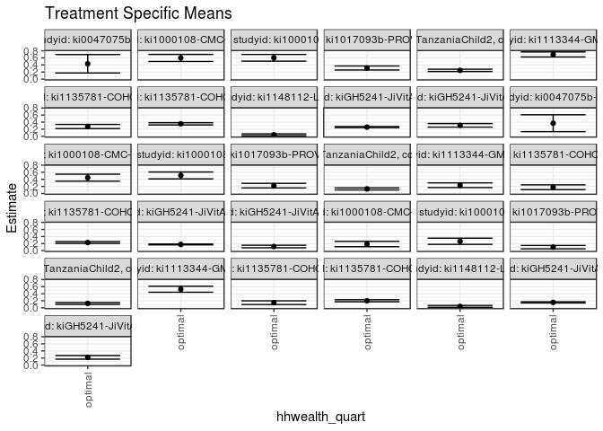

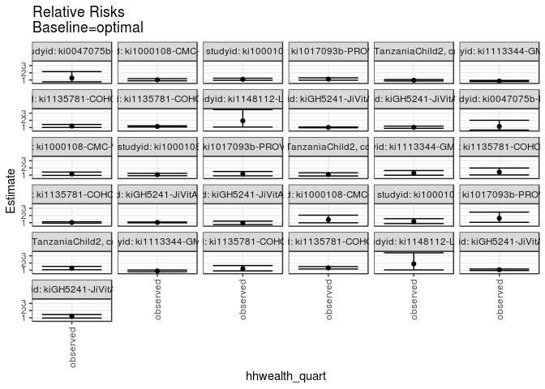

## Results Table

### Parameter: TSM

| agecat | studyid | country | intervention_level | baseline_level | estimate | ci_lower | ci_upper |
| --- | --- | --- | --- | --- | --- | --- | --- |
| 0-24 months | ki0047075b-MAL-ED | INDIA | optimal | NA | 0.4330379 | 0.1722744 | 0.6938015 |
| 0-24 months | ki1000108-CMC-V-BCS-2002 | INDIA | optimal | NA | 0.5987733 | 0.4994461 | 0.6981005 |
| 0-24 months | ki1000108-IRC | INDIA | optimal | NA | 0.6023576 | 0.5073865 | 0.6973287 |
| 0-24 months | ki1017093b-PROVIDE | BANGLADESH | optimal | NA | 0.3137169 | 0.2573400 | 0.3700938 |
| 0-24 months | ki1066203-TanzaniaChild2 | TANZANIA, UNITED REPUBLIC OF | optimal | NA | 0.2473766 | 0.2154846 | 0.2792687 |
| 0-24 months | ki1113344-GMS-Nepal | NEPAL | optimal | NA | 0.6975681 | 0.6256927 | 0.7694434 |
| 0-24 months | ki1135781-COHORTS | GUATEMALA | optimal | NA | 0.2768209 | 0.2179731 | 0.3356687 |
| 0-24 months | ki1135781-COHORTS | PHILIPPINES | optimal | NA | 0.3526829 | 0.3214926 | 0.3838733 |
| 0-24 months | ki1148112-LCNI-5 | MALAWI | optimal | NA | 0.0418595 | 0.0150482 | 0.0686709 |
| 0-24 months | kiGH5241-JiVitA-3 | BANGLADESH | optimal | NA | 0.2600410 | 0.2444958 | 0.2755863 |
| 0-24 months | kiGH5241-JiVitA-4 | BANGLADESH | optimal | NA | 0.3095813 | 0.2589963 | 0.3601663 |
| 0-6 months | ki0047075b-MAL-ED | INDIA | optimal | NA | 0.3691707 | 0.1306155 | 0.6077258 |
| 0-6 months | ki1000108-CMC-V-BCS-2002 | INDIA | optimal | NA | 0.4466418 | 0.3477854 | 0.5454983 |
| 0-6 months | ki1000108-IRC | INDIA | optimal | NA | 0.5097368 | 0.4116144 | 0.6078592 |
| 0-6 months | ki1017093b-PROVIDE | BANGLADESH | optimal | NA | 0.2221076 | 0.1572204 | 0.2869949 |
| 0-6 months | ki1066203-TanzaniaChild2 | TANZANIA, UNITED REPUBLIC OF | optimal | NA | 0.1294157 | 0.0998766 | 0.1589547 |
| 0-6 months | ki1113344-GMS-Nepal | NEPAL | optimal | NA | 0.2332566 | 0.1665381 | 0.2999750 |
| 0-6 months | ki1135781-COHORTS | GUATEMALA | optimal | NA | 0.1764846 | 0.1102496 | 0.2427197 |
| 0-6 months | ki1135781-COHORTS | PHILIPPINES | optimal | NA | 0.2302520 | 0.2045331 | 0.2559709 |
| 0-6 months | kiGH5241-JiVitA-3 | BANGLADESH | optimal | NA | 0.1762304 | 0.1643601 | 0.1881008 |
| 0-6 months | kiGH5241-JiVitA-4 | BANGLADESH | optimal | NA | 0.1177878 | 0.0808765 | 0.1546991 |
| 6-24 months | ki1000108-CMC-V-BCS-2002 | INDIA | optimal | NA | 0.1871850 | 0.1116519 | 0.2627181 |
| 6-24 months | ki1000108-IRC | INDIA | optimal | NA | 0.2656885 | 0.1781070 | 0.3532700 |
| 6-24 months | ki1017093b-PROVIDE | BANGLADESH | optimal | NA | 0.1004173 | 0.0531886 | 0.1476459 |
| 6-24 months | ki1066203-TanzaniaChild2 | TANZANIA, UNITED REPUBLIC OF | optimal | NA | 0.1255208 | 0.0993010 | 0.1517405 |
| 6-24 months | ki1113344-GMS-Nepal | NEPAL | optimal | NA | 0.5271320 | 0.4428315 | 0.6114325 |
| 6-24 months | ki1135781-COHORTS | GUATEMALA | optimal | NA | 0.1464278 | 0.0940576 | 0.1987979 |
| 6-24 months | ki1135781-COHORTS | PHILIPPINES | optimal | NA | 0.2006227 | 0.1724652 | 0.2287802 |
| 6-24 months | ki1148112-LCNI-5 | MALAWI | optimal | NA | 0.0415440 | 0.0147091 | 0.0683788 |
| 6-24 months | kiGH5241-JiVitA-3 | BANGLADESH | optimal | NA | 0.1548940 | 0.1378760 | 0.1719120 |
| 6-24 months | kiGH5241-JiVitA-4 | BANGLADESH | optimal | NA | 0.2178828 | 0.1678628 | 0.2679029 |

### Parameter: E(Y)

| agecat | studyid | country | intervention_level | baseline_level | estimate | ci_lower | ci_upper |
| --- | --- | --- | --- | --- | --- | --- | --- |
| 0-24 months | ki0047075b-MAL-ED | INDIA | observed | NA | 0.5492958 | 0.4327362 | 0.6658554 |
| 0-24 months | ki1000108-CMC-V-BCS-2002 | INDIA | observed | NA | 0.6139410 | 0.5644682 | 0.6634139 |
| 0-24 months | ki1000108-IRC | INDIA | observed | NA | 0.6560976 | 0.6100625 | 0.7021326 |
| 0-24 months | ki1017093b-PROVIDE | BANGLADESH | observed | NA | 0.3510029 | 0.3155698 | 0.3864359 |
| 0-24 months | ki1066203-TanzaniaChild2 | TANZANIA, UNITED REPUBLIC OF | observed | NA | 0.2365772 | 0.2195142 | 0.2536402 |
| 0-24 months | ki1113344-GMS-Nepal | NEPAL | observed | NA | 0.5913621 | 0.5520608 | 0.6306634 |
| 0-24 months | ki1135781-COHORTS | GUATEMALA | observed | NA | 0.3311367 | 0.2936667 | 0.3686068 |
| 0-24 months | ki1135781-COHORTS | PHILIPPINES | observed | NA | 0.4037451 | 0.3863123 | 0.4211779 |
| 0-24 months | ki1148112-LCNI-5 | MALAWI | observed | NA | 0.0807834 | 0.0620863 | 0.0994804 |
| 0-24 months | kiGH5241-JiVitA-3 | BANGLADESH | observed | NA | 0.2642331 | 0.2551503 | 0.2733160 |
| 0-24 months | kiGH5241-JiVitA-4 | BANGLADESH | observed | NA | 0.3184358 | 0.2901120 | 0.3467596 |
| 0-6 months | ki0047075b-MAL-ED | INDIA | observed | NA | 0.4225352 | 0.3068192 | 0.5382512 |
| 0-6 months | ki1000108-CMC-V-BCS-2002 | INDIA | observed | NA | 0.5190217 | 0.4679041 | 0.5701394 |
| 0-6 months | ki1000108-IRC | INDIA | observed | NA | 0.5439024 | 0.4956326 | 0.5921723 |
| 0-6 months | ki1017093b-PROVIDE | BANGLADESH | observed | NA | 0.2578797 | 0.2254025 | 0.2903568 |
| 0-6 months | ki1066203-TanzaniaChild2 | TANZANIA, UNITED REPUBLIC OF | observed | NA | 0.1392617 | 0.1253610 | 0.1531625 |
| 0-6 months | ki1113344-GMS-Nepal | NEPAL | observed | NA | 0.2956811 | 0.2591967 | 0.3321655 |
| 0-6 months | ki1135781-COHORTS | GUATEMALA | observed | NA | 0.2510373 | 0.2122871 | 0.2897876 |
| 0-6 months | ki1135781-COHORTS | PHILIPPINES | observed | NA | 0.2356227 | 0.2205417 | 0.2507038 |
| 0-6 months | kiGH5241-JiVitA-3 | BANGLADESH | observed | NA | 0.1822842 | 0.1742752 | 0.1902932 |
| 0-6 months | kiGH5241-JiVitA-4 | BANGLADESH | observed | NA | 0.1106095 | 0.0909057 | 0.1303132 |
| 6-24 months | ki1000108-CMC-V-BCS-2002 | INDIA | observed | NA | 0.2654155 | 0.2205451 | 0.3102860 |
| 6-24 months | ki1000108-IRC | INDIA | observed | NA | 0.3097561 | 0.2649438 | 0.3545684 |
| 6-24 months | ki1017093b-PROVIDE | BANGLADESH | observed | NA | 0.1615008 | 0.1323460 | 0.1906557 |
| 6-24 months | ki1066203-TanzaniaChild2 | TANZANIA, UNITED REPUBLIC OF | observed | NA | 0.1606965 | 0.1446374 | 0.1767556 |
| 6-24 months | ki1113344-GMS-Nepal | NEPAL | observed | NA | 0.4728814 | 0.4325613 | 0.5132014 |
| 6-24 months | ki1135781-COHORTS | GUATEMALA | observed | NA | 0.1783784 | 0.1464997 | 0.2102571 |
| 6-24 months | ki1135781-COHORTS | PHILIPPINES | observed | NA | 0.2666429 | 0.2502871 | 0.2829988 |
| 6-24 months | ki1148112-LCNI-5 | MALAWI | observed | NA | 0.0782609 | 0.0596958 | 0.0968259 |
| 6-24 months | kiGH5241-JiVitA-3 | BANGLADESH | observed | NA | 0.1648146 | 0.1556271 | 0.1740021 |
| 6-24 months | kiGH5241-JiVitA-4 | BANGLADESH | observed | NA | 0.2573427 | 0.2311603 | 0.2835250 |

### Parameter: RR

| agecat | studyid | country | intervention_level | baseline_level | estimate | ci_lower | ci_upper |
| --- | --- | --- | --- | --- | --- | --- | --- |
| 0-24 months | ki0047075b-MAL-ED | INDIA | observed | optimal | 1.2684703 | 0.7431406 | 2.1651582 |
| 0-24 months | ki1000108-CMC-V-BCS-2002 | INDIA | observed | optimal | 1.0253313 | 0.8882102 | 1.1836210 |
| 0-24 months | ki1000108-IRC | INDIA | observed | optimal | 1.0892160 | 0.9517834 | 1.2464933 |
| 0-24 months | ki1017093b-PROVIDE | BANGLADESH | observed | optimal | 1.1188523 | 0.9686472 | 1.2923492 |
| 0-24 months | ki1066203-TanzaniaChild2 | TANZANIA, UNITED REPUBLIC OF | observed | optimal | 0.9563440 | 0.8578169 | 1.0661878 |
| 0-24 months | ki1113344-GMS-Nepal | NEPAL | observed | optimal | 0.8477483 | 0.7717848 | 0.9311885 |
| 0-24 months | ki1135781-COHORTS | GUATEMALA | observed | optimal | 1.1962129 | 1.0057101 | 1.4228011 |
| 0-24 months | ki1135781-COHORTS | PHILIPPINES | observed | optimal | 1.1447820 | 1.0611853 | 1.2349641 |
| 0-24 months | ki1148112-LCNI-5 | MALAWI | observed | optimal | 1.9298672 | 1.0661826 | 3.4931983 |
| 0-24 months | kiGH5241-JiVitA-3 | BANGLADESH | observed | optimal | 1.0161209 | 0.9628936 | 1.0722905 |
| 0-24 months | kiGH5241-JiVitA-4 | BANGLADESH | observed | optimal | 1.0286014 | 0.8842090 | 1.1965731 |
| 0-6 months | ki0047075b-MAL-ED | INDIA | observed | optimal | 1.1445525 | 0.6524466 | 2.0078279 |
| 0-6 months | ki1000108-CMC-V-BCS-2002 | INDIA | observed | optimal | 1.1620536 | 0.9552027 | 1.4136984 |
| 0-6 months | ki1000108-IRC | INDIA | observed | optimal | 1.0670260 | 0.9090520 | 1.2524526 |
| 0-6 months | ki1017093b-PROVIDE | BANGLADESH | observed | optimal | 1.1610572 | 0.8968004 | 1.5031816 |
| 0-6 months | ki1066203-TanzaniaChild2 | TANZANIA, UNITED REPUBLIC OF | observed | optimal | 1.0760808 | 0.8773187 | 1.3198737 |
| 0-6 months | ki1113344-GMS-Nepal | NEPAL | observed | optimal | 1.2676216 | 0.9825602 | 1.6353853 |
| 0-6 months | ki1135781-COHORTS | GUATEMALA | observed | optimal | 1.4224320 | 1.0197727 | 1.9840821 |
| 0-6 months | ki1135781-COHORTS | PHILIPPINES | observed | optimal | 1.0233255 | 0.9358921 | 1.1189271 |
| 0-6 months | kiGH5241-JiVitA-3 | BANGLADESH | observed | optimal | 1.0343516 | 0.9794870 | 1.0922893 |
| 0-6 months | kiGH5241-JiVitA-4 | BANGLADESH | observed | optimal | 0.9390575 | 0.7281119 | 1.2111174 |
| 6-24 months | ki1000108-CMC-V-BCS-2002 | INDIA | observed | optimal | 1.4179316 | 0.9833778 | 2.0445144 |
| 6-24 months | ki1000108-IRC | INDIA | observed | optimal | 1.1658618 | 0.8734028 | 1.5562507 |
| 6-24 months | ki1017093b-PROVIDE | BANGLADESH | observed | optimal | 1.6082972 | 1.0499407 | 2.4635865 |
| 6-24 months | ki1066203-TanzaniaChild2 | TANZANIA, UNITED REPUBLIC OF | observed | optimal | 1.2802386 | 1.0688184 | 1.5334792 |
| 6-24 months | ki1113344-GMS-Nepal | NEPAL | observed | optimal | 0.8970833 | 0.7821542 | 1.0289001 |
| 6-24 months | ki1135781-COHORTS | GUATEMALA | observed | optimal | 1.2182004 | 0.8988100 | 1.6510855 |
| 6-24 months | ki1135781-COHORTS | PHILIPPINES | observed | optimal | 1.3290766 | 1.1728963 | 1.5060535 |
| 6-24 months | ki1148112-LCNI-5 | MALAWI | observed | optimal | 1.8838082 | 1.0377672 | 3.4195854 |
| 6-24 months | kiGH5241-JiVitA-3 | BANGLADESH | observed | optimal | 1.0640477 | 0.9654036 | 1.1727711 |
| 6-24 months | kiGH5241-JiVitA-4 | BANGLADESH | observed | optimal | 1.1811058 | 0.9610863 | 1.4514938 |

### Parameter: PAR

| agecat | studyid | country | intervention_level | baseline_level | estimate | ci_lower | ci_upper |
| --- | --- | --- | --- | --- | --- | --- | --- |
| 0-24 months | ki0047075b-MAL-ED | INDIA | optimal | NA | 0.1162578 | -0.1131377 | 0.3456534 |
| 0-24 months | ki1000108-CMC-V-BCS-2002 | INDIA | optimal | NA | 0.0151677 | -0.0707806 | 0.1011160 |
| 0-24 months | ki1000108-IRC | INDIA | optimal | NA | 0.0537400 | -0.0272433 | 0.1347232 |
| 0-24 months | ki1017093b-PROVIDE | BANGLADESH | optimal | NA | 0.0372860 | -0.0079245 | 0.0824965 |
| 0-24 months | ki1066203-TanzaniaChild2 | TANZANIA, UNITED REPUBLIC OF | optimal | NA | -0.0107995 | -0.0376873 | 0.0160883 |
| 0-24 months | ki1113344-GMS-Nepal | NEPAL | optimal | NA | -0.1062060 | -0.1705851 | -0.0418268 |
| 0-24 months | ki1135781-COHORTS | GUATEMALA | optimal | NA | 0.0543158 | 0.0062629 | 0.1023688 |
| 0-24 months | ki1135781-COHORTS | PHILIPPINES | optimal | NA | 0.0510621 | 0.0242978 | 0.0778265 |
| 0-24 months | ki1148112-LCNI-5 | MALAWI | optimal | NA | 0.0389238 | 0.0126447 | 0.0652029 |
| 0-24 months | kiGH5241-JiVitA-3 | BANGLADESH | optimal | NA | 0.0041921 | -0.0098196 | 0.0182038 |
| 0-24 months | kiGH5241-JiVitA-4 | BANGLADESH | optimal | NA | 0.0088544 | -0.0380996 | 0.0558085 |
| 0-6 months | ki0047075b-MAL-ED | INDIA | optimal | NA | 0.0533645 | -0.1533710 | 0.2601001 |
| 0-6 months | ki1000108-CMC-V-BCS-2002 | INDIA | optimal | NA | 0.0723799 | -0.0153016 | 0.1600614 |
| 0-6 months | ki1000108-IRC | INDIA | optimal | NA | 0.0341656 | -0.0471906 | 0.1155218 |
| 0-6 months | ki1017093b-PROVIDE | BANGLADESH | optimal | NA | 0.0357720 | -0.0215714 | 0.0931155 |
| 0-6 months | ki1066203-TanzaniaChild2 | TANZANIA, UNITED REPUBLIC OF | optimal | NA | 0.0098461 | -0.0165898 | 0.0362819 |
| 0-6 months | ki1113344-GMS-Nepal | NEPAL | optimal | NA | 0.0624245 | 0.0027151 | 0.1221339 |
| 0-6 months | ki1135781-COHORTS | GUATEMALA | optimal | NA | 0.0745527 | 0.0153978 | 0.1337076 |
| 0-6 months | ki1135781-COHORTS | PHILIPPINES | optimal | NA | 0.0053707 | -0.0151844 | 0.0259259 |
| 0-6 months | kiGH5241-JiVitA-3 | BANGLADESH | optimal | NA | 0.0060538 | -0.0035748 | 0.0156824 |
| 0-6 months | kiGH5241-JiVitA-4 | BANGLADESH | optimal | NA | -0.0071783 | -0.0371978 | 0.0228413 |
| 6-24 months | ki1000108-CMC-V-BCS-2002 | INDIA | optimal | NA | 0.0782305 | 0.0084968 | 0.1479643 |
| 6-24 months | ki1000108-IRC | INDIA | optimal | NA | 0.0440676 | -0.0326038 | 0.1207390 |
| 6-24 months | ki1017093b-PROVIDE | BANGLADESH | optimal | NA | 0.0610835 | 0.0173359 | 0.1048312 |
| 6-24 months | ki1066203-TanzaniaChild2 | TANZANIA, UNITED REPUBLIC OF | optimal | NA | 0.0351758 | 0.0123523 | 0.0579992 |
| 6-24 months | ki1113344-GMS-Nepal | NEPAL | optimal | NA | -0.0542507 | -0.1265698 | 0.0180685 |
| 6-24 months | ki1135781-COHORTS | GUATEMALA | optimal | NA | 0.0319506 | -0.0127526 | 0.0766538 |
| 6-24 months | ki1135781-COHORTS | PHILIPPINES | optimal | NA | 0.0660202 | 0.0406965 | 0.0913440 |
| 6-24 months | ki1148112-LCNI-5 | MALAWI | optimal | NA | 0.0367169 | 0.0106203 | 0.0628135 |
| 6-24 months | kiGH5241-JiVitA-3 | BANGLADESH | optimal | NA | 0.0099206 | -0.0051846 | 0.0250258 |
| 6-24 months | kiGH5241-JiVitA-4 | BANGLADESH | optimal | NA | 0.0394598 | -0.0056476 | 0.0845673 |

### Parameter: PAF

| agecat | studyid | country | intervention_level | baseline_level | estimate | ci_lower | ci_upper |
| --- | --- | --- | --- | --- | --- | --- | --- |
| 0-24 months | ki0047075b-MAL-ED | INDIA | optimal | NA | 0.2116489 | -0.3456404 | 0.5381400 |
| 0-24 months | ki1000108-CMC-V-BCS-2002 | INDIA | optimal | NA | 0.0247055 | -0.1258597 | 0.1551350 |
| 0-24 months | ki1000108-IRC | INDIA | optimal | NA | 0.0819085 | -0.0506592 | 0.1977494 |
| 0-24 months | ki1017093b-PROVIDE | BANGLADESH | optimal | NA | 0.1062270 | -0.0323676 | 0.2262153 |
| 0-24 months | ki1066203-TanzaniaChild2 | TANZANIA, UNITED REPUBLIC OF | optimal | NA | -0.0456488 | -0.1657500 | 0.0620789 |
| 0-24 months | ki1113344-GMS-Nepal | NEPAL | optimal | NA | -0.1795955 | -0.2956980 | -0.0738964 |
| 0-24 months | ki1135781-COHORTS | GUATEMALA | optimal | NA | 0.1640284 | 0.0056776 | 0.2971611 |
| 0-24 months | ki1135781-COHORTS | PHILIPPINES | optimal | NA | 0.1264712 | 0.0576575 | 0.1902599 |
| 0-24 months | ki1148112-LCNI-5 | MALAWI | optimal | NA | 0.4818296 | 0.0620744 | 0.7137294 |
| 0-24 months | kiGH5241-JiVitA-3 | BANGLADESH | optimal | NA | 0.0158651 | -0.0385363 | 0.0674169 |
| 0-24 months | kiGH5241-JiVitA-4 | BANGLADESH | optimal | NA | 0.0278061 | -0.1309543 | 0.1642801 |
| 0-6 months | ki0047075b-MAL-ED | INDIA | optimal | NA | 0.1262961 | -0.5326926 | 0.5019493 |
| 0-6 months | ki1000108-CMC-V-BCS-2002 | INDIA | optimal | NA | 0.1394545 | -0.0468982 | 0.2926355 |
| 0-6 months | ki1000108-IRC | INDIA | optimal | NA | 0.0628157 | -0.1000471 | 0.2015666 |
| 0-6 months | ki1017093b-PROVIDE | BANGLADESH | optimal | NA | 0.1387160 | -0.1150753 | 0.3347444 |
| 0-6 months | ki1066203-TanzaniaChild2 | TANZANIA, UNITED REPUBLIC OF | optimal | NA | 0.0707018 | -0.1398366 | 0.2423518 |
| 0-6 months | ki1113344-GMS-Nepal | NEPAL | optimal | NA | 0.2111211 | -0.0177493 | 0.3885233 |
| 0-6 months | ki1135781-COHORTS | GUATEMALA | optimal | NA | 0.2969787 | 0.0193893 | 0.4959886 |
| 0-6 months | ki1135781-COHORTS | PHILIPPINES | optimal | NA | 0.0227938 | -0.0684992 | 0.1062867 |
| 0-6 months | kiGH5241-JiVitA-3 | BANGLADESH | optimal | NA | 0.0332107 | -0.0209426 | 0.0844916 |
| 0-6 months | kiGH5241-JiVitA-4 | BANGLADESH | optimal | NA | -0.0648976 | -0.3734154 | 0.1743162 |
| 6-24 months | ki1000108-CMC-V-BCS-2002 | INDIA | optimal | NA | 0.2947474 | -0.0169032 | 0.5108863 |
| 6-24 months | ki1000108-IRC | INDIA | optimal | NA | 0.1422654 | -0.1449471 | 0.3574300 |
| 6-24 months | ki1017093b-PROVIDE | BANGLADESH | optimal | NA | 0.3782244 | 0.0475653 | 0.5940877 |
| 6-24 months | ki1066203-TanzaniaChild2 | TANZANIA, UNITED REPUBLIC OF | optimal | NA | 0.2188956 | 0.0643874 | 0.3478881 |
| 6-24 months | ki1113344-GMS-Nepal | NEPAL | optimal | NA | -0.1147236 | -0.2785203 | 0.0280883 |
| 6-24 months | ki1135781-COHORTS | GUATEMALA | optimal | NA | 0.1791170 | -0.1125822 | 0.3943379 |
| 6-24 months | ki1135781-COHORTS | PHILIPPINES | optimal | NA | 0.2475979 | 0.1474097 | 0.3360130 |
| 6-24 months | ki1148112-LCNI-5 | MALAWI | optimal | NA | 0.4691604 | 0.0363927 | 0.7075669 |
| 6-24 months | kiGH5241-JiVitA-3 | BANGLADESH | optimal | NA | 0.0601925 | -0.0358362 | 0.1473187 |
| 6-24 months | kiGH5241-JiVitA-4 | BANGLADESH | optimal | NA | 0.1533358 | -0.0404893 | 0.3110546 |